# Practice 3 (Team 1)

### Loading data

```r
path <- 'https://raw.githubusercontent.com/Paul-scpark/Data_Mining_Practicum/main/data/'

covid_df <- read.csv(paste0(path, 'covid19_210903.csv'))
GDP <- read.csv(paste0(path, 'GDP_per_capita.csv'))
life_expectancy <- read.csv(paste0(path, 'Life_expectancy.csv'))
pop <- read.csv(paste0(path, 'population_total.csv'))
continent <- read.csv(paste0(path, 'continent_table.csv'))

colnames(GDP) <- GDP[2, ]
GDP <- GDP[3:199, ]
GDP <- gather(GDP, time, GDP, 3:243)
colnames(GDP)[2] <- 'name'

pop <- gather(pop, time, POP, 2:302)
pop$time <- gsub('X', '', pop$time)
```

### Preprocessing

```r
str(GDP)
```

```
## 'data.frame':    47477 obs. of  4 variables:
##  $ geo : chr  "afg" "alb" "dza" "and" ...
##  $ name: chr  "Afghanistan" "Albania" "Algeria" "Andorra" ...
##  $ time: chr  "1800" "1800" "1800" "1800" ...
##  $ GDP : int  603 667 715 1197 618 757 1635 514 817 1847 ...
```

```r
str(life_expectancy)
```

```
## 'data.frame':    56130 obs. of  4 variables:
##  $ geo            : chr  "afg" "afg" "afg" "afg" ...
##  $ name           : chr  "Afghanistan" "Afghanistan" "Afghanistan" "Afghanistan" ...
##  $ time           : int  1800 1801 1802 1803 1804 1805 1806 1807 1808 1809 ...
##  $ Life.expectancy: num  28.2 28.2 28.2 28.2 28.2 ...
```

```r
str(pop)
```

```
## 'data.frame':    58695 obs. of  3 variables:
##  $ country: chr  "Afghanistan" "Albania" "Algeria" "Andorra" ...
##  $ time   : chr  "1800" "1800" "1800" "1800" ...
##  $ POP    : int  3280000 400000 2500000 2650 1570000 37000 534000 413000 200000 3000000 ...
```

```r
life_expectancy$time <- as.character(life_expectancy$time)
```

str 함수를 통해서 데이터들의 형태를 확인하도록 한다.

GDP 데이터에서 time(연도) 변수는 문자형으로 되어있는데, life_expectancy 데이터는 숫자형이므로 이를 맞춰준다.

```r
unique(GDP$geo) %>% length()
```

```
## [1] 197
```

```r
unique(life_expectancy$geo) %>% length()
```

```
## [1] 189
```

```r
unique(pop$country) %>% length()
```

```
## [1] 195
```

각 데이터들의 분포를 확인하기 위해서 가장 먼저 고유한 국가의 개수가 몇 개씩 있는지 확인해보도록 한다.

GDP 데이터는 197개의 국가가, life_expectancy 데이터는 189개 국가, pop 데이터는 195개 국가가 있다.

```r
colSums(is.na(GDP))
```

```
##  geo name time  GDP
##    0    0    0  482
```

```r
colSums(is.na(life_expectancy))
```

```
##             geo            name            time Life.expectancy
##               0               0               0               0
```

```r
colSums(is.na(pop))
```

```
## country    time     POP
##       0       0       0
```

```r
unique(GDP[is.na(GDP$GDP), ]$geo)
```

```
## [1] "hos" "lie"
```

```r
GDP <- drop_na(GDP)
```

혹시 데이터에 NA가 포함된 데이터가 있는지도 확인해보도록 한다.

life_expectancy와 pop 데이터는 각 변수 별로 NA는 하나도 없음을 확인할 수 있었다.

하지만 GDP 데이터는 GDP를 뜻하는 변수에서 NA가 482개가 있었음을 확인할 수 있었다.

어떤 국가에서 NA가 있는지를 확인해보니, hos, lie 라는 2개의 국가에서 NA가 있었다.

따라서 이를 제거하고, 결과를 확인해보도록 한다.

```r
total_df <- inner_join(GDP, life_expectancy, by = c('geo', 'time', 'name'))
total_df <- total_df[order(total_df$geo), ]
row.names(total_df) <- NULL

unique(total_df$geo) %>% length()
```

```
## [1] 189
```

```r
colSums(is.na(total_df))
```

```
##             geo            name            time             GDP Life.expectancy
##               0               0               0               0               0
```

GDP와 life_expectancy의 국가 수에 약간의 차이가 있으므로, inner_join으로 두 데이터를 묶어주도록 한다.

데이터를 merge 한 후, 고유한 국가 수를 확인해보면 189개가 나오는 것을 볼 수 있다.

또한 NA도 하나도 없다는 것을 확인할 수 있다.

```r
setdiff(total_df$name, pop$country)
```

```
## [1] "Hong Kong, China" "Macedonia, FYR"   "Swaziland"        "Taiwan"
```

```r
setdiff(pop$country, total_df$name)
```

```
##  [1] "Eswatini"            "Holy See"            "Liechtenstein"
##  [4] "Monaco"              "Nauru"               "North Macedonia"
##  [7] "Palau"               "San Marino"          "St. Kitts and Nevis"
## [10] "Tuvalu"
```

```r
total_df <- left_join(total_df, pop, by = c('name' = 'country', 'time'))
unique(total_df[is.na(total_df$POP), ]$name)
```

```
## [1] "Hong Kong, China" "Macedonia, FYR"   "Swaziland"        "Taiwan"
```

한편, 인구 수를 담고 있는 pop 데이터도 함께 묶어주도록 한다.

다만, GDP와 기대수명을 함께 묶은 데이터와 인구 수 데이터 사이에 함께 있지 않은 국가들이 일부가 있다.

따라서 GDP와 기대수명을 묶은 데이터를 기준으로 left_join 하여 기존에 189개 나라를 맞춰주도록 한다.

인구 수 데이터에서 누락된 홍콩, 마케도니아, 스와질랜드, 타이완은 인구 수에서 NA가 나오는 것을 볼 수 있다.

### 1-1. GDP & Life_expectancy’s correlation

```r
now_df <- total_df %>%
            filter(time == '2021') %>%
            mutate(pop = POP * 0.00001)

head(now_df)
```

```
##   geo                 name time   GDP Life.expectancy      POP   pop
## 1 afg          Afghanistan 2021  1846           64.74 39800000 398.0
## 2 ago               Angola 2021  5438           65.71 33900000 339.0
## 3 alb              Albania 2021 13775           78.70  2870000  28.7
## 4 are United Arab Emirates 2021 65094           73.90  9990000  99.9
## 5 arg            Argentina 2021 17170           77.25 45600000 456.0
## 6 arm              Armenia 2021 10652           76.18  2970000  29.7
```

GDP와 기대수명률 사이에 상관계수를 확인하기 위해 그래프를 그려보도록 한다.

먼저 위에서 묶은 데이터는 1800년부터 2040년까지 있는 데이터이므로, 현재인 2021년을 기점으로 결과를 보도록 한다.

또한 단순히 GDP와 기대수명률으로만 계산하지 않고, 인구 수도 함께 비교할 수 있도록 한다.

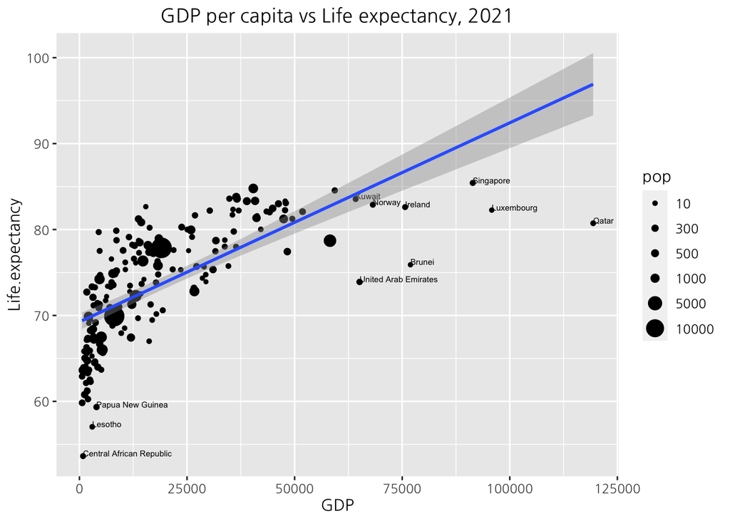

```r
now_df %>%
  ggplot(aes(x = GDP, y = Life.expectancy, label = name)) +
  geom_point(aes(size = pop)) +
  geom_text(aes(label=ifelse(GDP > 60000, as.character(name), '')), size = 2, hjust=0, vjust=0) +
  geom_text(aes(label=ifelse(Life.expectancy < 59.5, as.character(name), '')), size = 2, hjust=0, vjust=0) +
  scale_size_continuous(
    breaks = c(10, 300, 500, 1000, 5000, 10000)) +
  geom_smooth(method = lm) +
  ggtitle('GDP per capita vs Life expectancy, 2021') +
  theme(plot.title = element_text(hjust=0.5))
```

```r
cor(now_df$GDP, now_df$Life.expectancy, use = "all.obs", method = "pearson")
```

```
## [1] 0.6896472
```

X축을 GDP로, Y축을 기대수명으로 하여 그래프를 그려보면 다음과 같다.

또한 scatterplot의 사이즈는 인구 수로 설정하여 함께 비교해보도록 한다.

그리고 문제에 따라 피어슨 상관계수를 출력해보면, 약 0.69 정도의 값이 나오는 것을 볼 수 있다.

상관계수와 함께 그래프에 있는 회귀선을 통해 확인할 수 있듯, GDP의 값이 증가할수록 기대수명도 증가하는 것을 알 수 있다.

일반적으로 상관계수는 -1부터 1 사이의 값을 가지며, 1일때 높은 상관관계를 갖는다고 이야기한다.

현재 GDP와 기대수명 사이에 상관계수는 0.69 정도의 값을 가지기 때문에 비교적 높은 상관관계를 갖는다.

### 1-2. GDP(log) & Life_expectancy’s correlation

```r
now_df$GDP_log <- log(now_df$GDP)
head(now_df)
```

```
##   geo                 name time   GDP Life.expectancy      POP   pop   GDP_log
## 1 afg          Afghanistan 2021  1846           64.74 39800000 398.0  7.520776
## 2 ago               Angola 2021  5438           65.71 33900000 339.0  8.601167
## 3 alb              Albania 2021 13775           78.70  2870000  28.7  9.530611
## 4 are United Arab Emirates 2021 65094           73.90  9990000  99.9 11.083588
## 5 arg            Argentina 2021 17170           77.25 45600000 456.0  9.750919
## 6 arm              Armenia 2021 10652           76.18  2970000  29.7  9.273503
```

monetary value는 log-normal 분포를 가지기 때문에 GDP에 log를 취한 값을 새로운 변수로 만든다.

그 값을 위와 같이 head 함수로 확인할 수 있다.

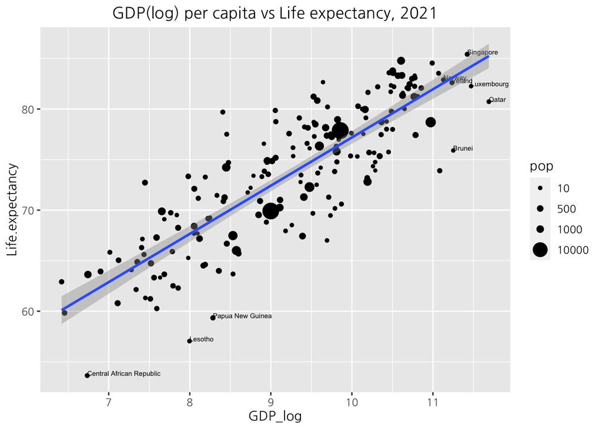

```r
now_df %>%
  ggplot(aes(x = GDP_log, y = Life.expectancy, label = name)) +
  geom_point(aes(size = pop)) +
  geom_text(aes(label=ifelse(GDP_log > 11.1, as.character(name), '')), size = 2, hjust=0, vjust=0) +
  geom_text(aes(label=ifelse(Life.expectancy < 59.5, as.character(name), '')), size = 2, hjust=0, vjust=0) +
  scale_size_continuous(
    breaks = c(0, 10, 500, 1000, 10000)) +
  geom_smooth(method = lm) +
  ggtitle('GDP(log) per capita vs Life expectancy, 2021') +
  theme(plot.title = element_text(hjust=0.5))
```

```r
cor(now_df$GDP_log, now_df$Life.expectancy, use = "all.obs", method = "pearson")
```

```
## [1] 0.8401122
```

그런 후에, 위에서 그렸던 그래프처럼 그래프를 그려보면 위와 같다.

또한 상관계수의 값을 출력해보면, 약 0.84의 값을 가지므로 log 전 값보다 더 높은 상관관계를 보인다.

그래프 상의 회귀선을 통해 확인할 수 있듯, GDP_log가 커질수록 기대수명도 증가하는 것을 확인할 수 있다.

### 2-1. Distribution of COVID-19 Confirmers and Death by Continent

```r
str(covid_df)
```

```
## 'data.frame':    399996 obs. of  7 variables:
##  $ date    : chr  "2020-01-22" "2020-01-22" "2020-01-22" "2020-01-22" ...
##  $ province: chr  "" "" "" "" ...
##  $ country : chr  "Afghanistan" "Albania" "Algeria" "Andorra" ...
##  $ lat     : num  33.9 41.2 28 42.5 -11.2 ...
##  $ long    : num  67.71 20.17 1.66 1.52 17.87 ...
##  $ type    : chr  "confirmed" "confirmed" "confirmed" "confirmed" ...
##  $ cases   : int  0 0 0 0 0 0 0 0 0 0 ...
```

```r
covid_df$date <- as.Date(covid_df$date)
covid_df %>%
  filter(date == '2020-01-22',
         country == 'Afghanistan') %>%
  head()
```

```
##         date province     country      lat     long      type cases
## 1 2020-01-22          Afghanistan 33.93911 67.70995 confirmed     0
## 2 2020-01-22          Afghanistan 33.93911 67.70995     death     0
## 3 2020-01-22          Afghanistan 33.93911 67.70995 recovered     0
```

대륙별로 코로나 확진자 수와 사망자 수를 그래프를 통해서 확인해보록 한다.

가장 먼저 covid_df에 대하여 date 변수를 날짜 형태로 변환해주도록 한다.

그리고 난 뒤에 한 날짜에 대하여 한 국가의 값을 확인해보면, type이 다른 3개의 값이 나오는 것을 볼 수 있다.

이는 같은 날짜, 같은 국가에 대하여 서로 다른 type이 들어가 있으므로 tidy한 데이터가 아니다.

따라서 type 변수에 대하여 spread를 통해 tidy 데이터 형태로 변환해주도록 한다.

```r
covid_df <- spread(covid_df, type, cases)
head(covid_df)
```

```
##         date province             country       lat      long confirmed death
## 1 2020-01-22                  Afghanistan  33.93911  67.70995         0     0
## 2 2020-01-22                      Albania  41.15330  20.16830         0     0
## 3 2020-01-22                      Algeria  28.03390   1.65960         0     0
## 4 2020-01-22                      Andorra  42.50630   1.52180         0     0
## 5 2020-01-22                       Angola -11.20270  17.87390         0     0
## 6 2020-01-22          Antigua and Barbuda  17.06080 -61.79640         0     0
##   recovered
## 1         0
## 2         0
## 3         0
## 4         0
## 5         0
## 6         0
```

이렇게 하면, 같은 날짜에 대하여 3개의 type들이 서로 다른 새로운 변수로 만들어지는 것을 확인할 수 있다.

```r
total_df <- total_df %>%
  mutate(name = replace(name, name == 'Congo, Rep.', 'Republic of Congo'),
         name = replace(name, name == 'Czech Republic', 'Czechia'),
         name = replace(name, name == 'Dominican Republic', 'Dominica'),
         name = replace(name, name == 'Lao', 'Laos'),
         name = replace(name, name == 'Micronesia, Fed. Sts.', 'Micronesia'),
         name = replace(name, name == 'Macedonia, FYR', 'North Macedonia'),
         name = replace(name, name == 'Slovak Republic', 'Slovakia'),
         name = replace(name, name == 'St. Lucia', 'Saint Lucia'),
         name = replace(name, name == 'St. Vincent and the Grenadines', 'Saint Vincent and the Grenadines'),
         name = replace(name, name == 'United States', 'USA'),
         name = replace(name, name == 'United Kingdom', 'UK'))

covid_df <- total_df %>%
              filter(time %in% c(2020, 2021)) %>%
              group_by(name) %>%
              summarise(GDP = mean(GDP),
                        Life.expectancy = mean(Life.expectancy),
                        POP = mean(POP)) %>%
              right_join(covid_df, by = c('name' = 'country')) %>%
              select(date, name, lat, long, GDP, Life.expectancy, POP, confirmed, death, recovered)

head(covid_df)
```

```
## # A tibble: 6 × 10
##   date       name        lat  long   GDP Life.expectancy     POP confirmed death
##   <date>     <chr>     <dbl> <dbl> <dbl>           <dbl>   <dbl>     <int> <int>
## 1 2020-01-22 Afghanis…  33.9  67.7  1823            64.6  3.94e7         0     0
## 2 2020-01-23 Afghanis…  33.9  67.7  1823            64.6  3.94e7         0     0
## 3 2020-01-24 Afghanis…  33.9  67.7  1823            64.6  3.94e7         0     0
## 4 2020-01-25 Afghanis…  33.9  67.7  1823            64.6  3.94e7         0     0
## 5 2020-01-26 Afghanis…  33.9  67.7  1823            64.6  3.94e7         0     0
## 6 2020-01-27 Afghanis…  33.9  67.7  1823            64.6  3.94e7         0     0
## # … with 1 more variable: recovered <int>
```

데이터를 merge 하기 전에, 표기법이 다른 일부 국가들에 대하여 국가 이름을 통일해주도록 한다.

그리고 코로나 데이터가 2020년부터 2021년까지 있으므로, 앞선 total_df에서 2020년과 2021년만 추려서 GDP와 기대수명, 인구수의 평균을 구해준다.

그 후에 코로나 데이터와 merge 시켜서 각 나라의 코로나 확진자 및 사망자 데이터와 함께 해당 국가의 GDP와 기대수명, 인구수를 알 수 있도록 한다.

최종적으로 head 함수를 통해서 잘 merge가 되었는지 확인해볼 수 있다.

```r
covid_df %>%
  group_by(name) %>%
  mutate(confirmed_cumsum = cumsum(replace_na(confirmed, 0)),
         death_cumsum = cumsum(replace_na(death, 0))) %>%
  filter(date == '2021-05-27', name == 'Australia')
```

```
## # A tibble: 8 × 12
## # Groups:   name [1]
##   date       name        lat  long   GDP Life.expectancy     POP confirmed death
##   <date>     <chr>     <dbl> <dbl> <dbl>           <dbl>   <dbl>     <int> <int>
## 1 2021-05-27 Australia -35.5  149. 46021            82.9  2.56e7         0     0
## 2 2021-05-27 Australia -33.9  151. 46021            82.9  2.56e7         3     0
## 3 2021-05-27 Australia -12.5  131. 46021            82.9  2.56e7         0     0
## 4 2021-05-27 Australia -27.5  153. 46021            82.9  2.56e7         2     0
## 5 2021-05-27 Australia -34.9  139. 46021            82.9  2.56e7         0     0
## 6 2021-05-27 Australia -42.9  147. 46021            82.9  2.56e7         0     0
## 7 2021-05-27 Australia -37.8  145. 46021            82.9  2.56e7         6     0
## 8 2021-05-27 Australia -32.0  116. 46021            82.9  2.56e7         0     0
## # … with 3 more variables: recovered <int>, confirmed_cumsum <dbl>,
## #   death_cumsum <dbl>
```

가장 현재 날짜인 2021년 5월 27일을 기준으로 2020년 1월 22일부터 현재까지 cumsum 함수로 누적 확진자와 사망자 수를 구한다.

한편, cumsum 함수는 NA가 있으면 NA를 반환하므로, replace_na 함수로 NA는 0으로 대체하도록 한다.

하지만 위에서 확인할 수 있듯, 같은 나라이지만 province에 따라 다수의 행이 출력되는 국가들이 있었다.

따라서 중복된 값을 제거하면서, 중복이 있는 경우에는 가장 마지막 값을 남겨두도록 한다.

```r
now_covid_df <- covid_df %>%
                  group_by(name) %>%
                  mutate(confirmed_cumsum = cumsum(replace_na(confirmed, 0)),
                         death_cumsum = cumsum(replace_na(death, 0))) %>%
                  filter(date == '2021-05-27') %>%
                  group_by(name) %>%
                  filter(row_number() == n()) %>%
                  select(-confirmed, -death, -recovered) %>%
                  left_join(continent[, c('continent', 'location')], by = c('name' = 'location'))

head(now_covid_df)
```

```
## # A tibble: 6 × 10
## # Groups:   name [6]
##   date       name      lat   long    GDP Life.expectancy    POP confirmed_cumsum
##   <date>     <chr>   <dbl>  <dbl>  <dbl>           <dbl>  <dbl>            <dbl>
## 1 2021-05-27 Afghan…  33.9  67.7   1823             64.6 3.94e7            68366
## 2 2021-05-27 Albania  41.2  20.2  13500             78.6 2.88e6           132264
## 3 2021-05-27 Algeria  28.0   1.66 14036.            78.4 4.42e7           127926
## 4 2021-05-27 Angola  -11.2  17.9   5441             65.5 3.34e7            33607
## 5 2021-05-27 Antigu…  17.1 -61.8  25184.            77.5 9.83e4             1258
## 6 2021-05-27 Argent… -38.4 -63.6  17142.            77.2 4.54e7          3663215
## # … with 2 more variables: death_cumsum <dbl>, continent <chr>
```

위에서 확인한 알고리즘에서 filter(row_number() == n()) 함수를 추가하여 중복된 country는 가장 마지막을 남겨두도록 한다.

또한 continent 데이터를 함께 merge 하여 대륙 정보도 함께 추가하도록 한다.

이를 통해 중복된 값이 없이, 192개 국가에 대한 데이터가 잘 출력된 것을 볼 수 있다.

```r
now_covid_df[is.na(now_covid_df$continent), ]
```

```
## # A tibble: 12 × 10
## # Groups:   name [12]
##    date       name                 lat    long    GDP Life.expectancy       POP
##    <date>     <chr>              <dbl>   <dbl>  <dbl>           <dbl>     <dbl>
##  1 2021-05-27 Kiribati           -3.37 -169.    2064.            63.2    120000
##  2 2021-05-27 Micronesia          7.43  151.    3270.            67.6    115500
##  3 2021-05-27 Republic of Congo  -4.04   21.8   5096.            63.6   5590000
##  4 2021-05-27 Timor-Leste        -8.87  126.    6548.            71.6   1330000
##  5 2021-05-27 UK                 55.4    -3.44 40945             81.3  68050000
##  6 2021-05-27 USA                40    -100    57875             78.7 332000000
##  7 2021-05-27 Burma              21.9    96.0     NA             NA          NA
##  8 2021-05-27 Cabo Verde         16.5   -23.0     NA             NA          NA
##  9 2021-05-27 Diamond Princess    0       0       NA             NA          NA
## 10 2021-05-27 Holy See           41.9    12.5     NA             NA          NA
## 11 2021-05-27 MS Zaandam          0       0       NA             NA          NA
## 12 2021-05-27 West Bank and Gaza 32.0    35.2     NA             NA          NA
## # … with 3 more variables: confirmed_cumsum <dbl>, death_cumsum <dbl>,
## #   continent <chr>
```

```r
now_covid_df[now_covid_df$name == 'USA', ]$continent <- 'North America'
now_covid_df[now_covid_df$name == 'UK', ]$continent <- 'Europe'
now_covid_df[now_covid_df$name == 'Kiribati', ]$continent <- 'Oceania'
now_covid_df[now_covid_df$name == 'Timor-Leste', ]$continent <- 'Asia'
now_covid_df[now_covid_df$name == 'Burma', ]$continent <- 'Asia'
now_covid_df[now_covid_df$name == 'Cabo Verde', ]$continent <- 'Africa'
now_covid_df[now_covid_df$name == 'Republic of Congo', ]$continent <- 'Africa'
now_covid_df[now_covid_df$name == 'Micronesia', ]$continent <- 'Oceania'
now_covid_df[now_covid_df$name == 'West Bank and Gaza', ]$continent <- 'Asia'
```

한편, continent가 NA인 값들도 나오게 되어 확인해보았다.

대부분의 국가들이 처음 들어보는 낯선 국가들이었는데, USA와 UK는 줄임 표현 때문에 인식을 못한 것으로 생각되었다.

따라서 이들을 각각 검색하여 알맞은 대륙으로 채워주도록 한다.

```r
now_covid_df$confirmed_per_10k <- now_covid_df$confirmed_cumsum / (now_covid_df$POP / 10000)
now_covid_df$death_per_10k <- now_covid_df$death_cumsum / (now_covid_df$POP / 10000)
head(now_covid_df)
```

```
## # A tibble: 6 × 12
## # Groups:   name [6]
##   date       name      lat   long    GDP Life.expectancy    POP confirmed_cumsum
##   <date>     <chr>   <dbl>  <dbl>  <dbl>           <dbl>  <dbl>            <dbl>
## 1 2021-05-27 Afghan…  33.9  67.7   1823             64.6 3.94e7            68366
## 2 2021-05-27 Albania  41.2  20.2  13500             78.6 2.88e6           132264
## 3 2021-05-27 Algeria  28.0   1.66 14036.            78.4 4.42e7           127926
## 4 2021-05-27 Angola  -11.2  17.9   5441             65.5 3.34e7            33607
## 5 2021-05-27 Antigu…  17.1 -61.8  25184.            77.5 9.83e4             1258
## 6 2021-05-27 Argent… -38.4 -63.6  17142.            77.2 4.54e7          3663215
## # … with 4 more variables: death_cumsum <dbl>, continent <chr>,
## #   confirmed_per_10k <dbl>, death_per_10k <dbl>
```

그리고 누적 확진자 수와 인구 수를 통해서 인구 만 명당 확진자 수와 사망자 수를 확인하도록 한다.

각각에 대하여 새로운 열을 만들어주고, head 함수로 새로운 변수들이 잘 만들어졌는지 확인하도록 한다.

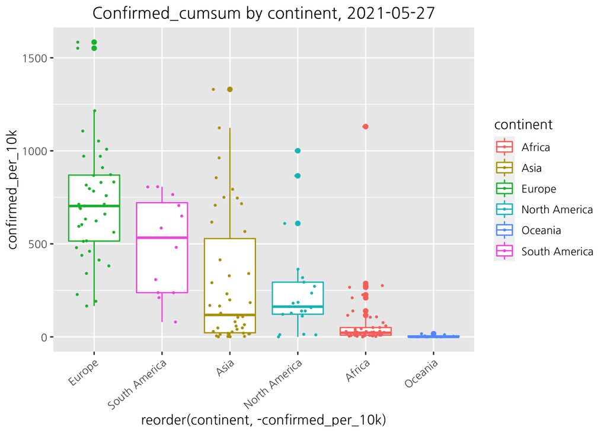

```r
now_covid_df %>%
  filter(!is.na(confirmed_per_10k)) %>%
  ggplot(aes(x = reorder(continent, -confirmed_per_10k), y = confirmed_per_10k)) +
  geom_boxplot(aes(color = continent)) +
  geom_jitter(aes(color = continent), position=position_jitter(width=0.3, height=0.2), size=0.5) +
  ggtitle('Confirmed_cumsum by continent, 2021-05-27') +
  theme(plot.title = element_text(hjust=0.5),
        axis.text.x=element_text(angle=40, hjust=1))
```

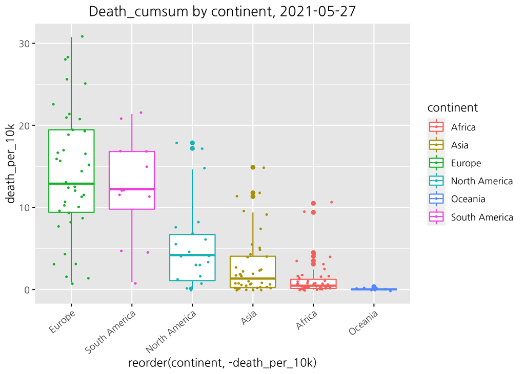

```r
now_covid_df %>%
  filter(!is.na(death_per_10k)) %>%
  ggplot(aes(x = reorder(continent, -death_per_10k), y = death_per_10k)) +
  geom_boxplot(aes(color = continent)) +
  geom_jitter(aes(color = continent), position=position_jitter(width=0.3, height=0.2), size=0.5) +
  ggtitle('Death_cumsum by continent, 2021-05-27') +
  theme(plot.title = element_text(hjust=0.5),
        axis.text.x=element_text(angle=40, hjust=1))
```

단위 수가 너무 크기 때문에 인구 만 명당 누적 확진자와 사망자 수를 확인한다. 최종적으로 이를 대륙 별로 boxplot을 통해 그 분포를 확인하도록 한다.

전반적으로 누적 확진자와 사망자 수의 분포는 비슷한 모양을 보인다. 이를 각 대륙별 평균값으로 확인해보면 다음과 같다.

```r
now_covid_df %>%
  filter(!is.na(confirmed_per_10k)) %>%
  group_by(continent) %>%
  summarise(mean_confirmed = mean(confirmed_per_10k),
            mean_death = mean(death_per_10k)) %>%
  arrange(desc(mean_confirmed))
```

```
## # A tibble: 6 × 3
##   continent     mean_confirmed mean_death
##   <chr>                  <dbl>      <dbl>
## 1 Europe                724.      14.2
## 2 South America         490.      12.4
## 3 Asia                  294.       2.83
## 4 North America         254.       5.28
## 5 Africa                 72.6      1.18
## 6 Oceania                 4.29     0.0738
```

누적 확진자 수의 평균은 유럽 - 남아메리카 - 아시아 - 북아메리카 - 아프리카 - 오세아니아 순서를 보인다.

한편, 누적 사망자 수의 평균은 유럽 - 남아메리카 - 북아메리카 - 아시아 - 아프리카 - 오세아니아 순서를 보인다.

전반적으로 유럽과 아메리카 대륙에서 확진자와 사망자 수가 많았다는 것을 확인할 수 있다.

### 3-1. Comparison of COVID-19 situation by countries

```r
top_confirmed_countries <- now_covid_df %>%
                            arrange(desc(confirmed_cumsum)) %>%
                            select(name) %>%
                            head(5) %>%
                            as.matrix() %>%
                            c()

top_death_countries <- now_covid_df %>%
                         arrange(desc(death_cumsum)) %>%
                         select(name) %>%
                         head(5) %>%
                         as.matrix() %>%
                         c()

top_confirmed_countries
```

```
## [1] "USA"    "India"  "Brazil" "France" "Turkey"
```

```r
top_death_countries
```

```
## [1] "USA"    "Brazil" "India"  "Mexico" "UK"
```

그렇다면, 국가별로 코로나 바이러스의 상황을 비교하기 위해 추가적인 시각화를 수행해보도록 한다.

먼저는 가장 최근 날짜 (2021-05-27) 기준으로 누적 확진자와 사망자 수가 많았던 상위 5개 국가들에 대해 Daily 변화 추이를 그래프로 확인한다.

이를 위해서 누적 확진자와 누적 사망자 수의 상위 5개 국가들을 각각 출력하여 확인해보도록 한다.

누적 확진자 수가 가장 많았던 상위 5개 국가는 미국, 인도, 브라질, 프랑스, 터키였다.

또한 누적 사망자 수가 가장 많았던 상위 5개 국가는 미국, 브라질, 인도, 멕시코, 영국이었다.

미국과 브라질, 멕시코가 아메리카 대륙으로 속한 것으로 보아 2번 과정에서 아메리카 대륙이 상위에 속한 이유들에 대해 다시 생각해볼 수 있다.

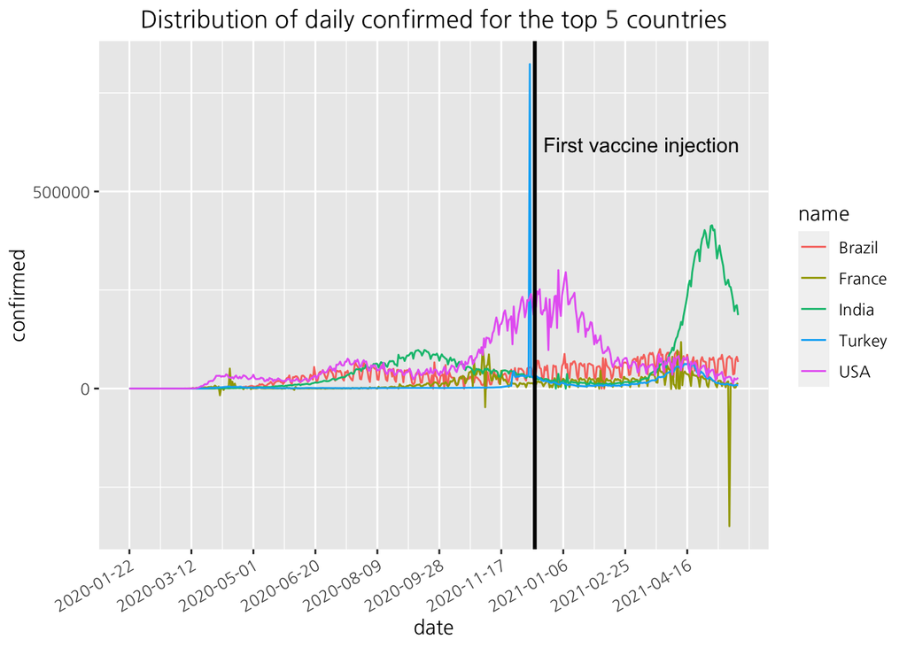

```r
covid_df %>%
  filter(name %in% top_confirmed_countries) %>%
  group_by(name, date) %>%
  filter(row_number() == n()) %>%
  ggplot(aes(x = date, y = confirmed, group = name)) +
  geom_line(aes(color = name)) +
  geom_vline(xintercept = as.numeric(ymd("2020-12-14")),
             color = 'black', size = 1) +
  geom_text(aes(x = as.Date('2020-11-01'), y = 600000, label = 'First vaccine injection'),
            size = 4, vjust = 0, hjust = 0, nudge_x = 50, check_overlap = TRUE) +
  scale_x_continuous(breaks = seq(min(covid_df$date), max(covid_df$date), by = 50)) +
  ggtitle('Distribution of daily confirmed for the top 5 countries') +
  theme(plot.title = element_text(hjust=0.5),
        axis.text.x=element_text(angle=30, hjust=1))
```

첫번째는 누적 확진자 수가 가장 많았던 미국, 인도, 브라질, 프랑스, 터키에 대하여 2020년 1월 22일부터 2021년 5월 27일까지 결과를 확인한다.

먼저는 누적이 아닌, 각 날짜별로 확진자가 얼마나 나왔는지를 line 그래프를 통해서 확인해보도록 한다.

그래프에 대한 설명을 하기 전에 확진자 수이긴 한데, 데이터 상에서 음수를 표현하는 값들이 있다.

해당 값들은 Outlier인지, 아니면 확진 되었다가 회복되었는지 등 특별히 알 수 있는 방법이 없어 우선 그대로 두도록 했다.

인터넷 기사를 확인해보니, 코로나 19 백신이 2020년 12월 14일에 미국에서 처음으로 투여되었다고 한다. 따라서 이 날짜를 선으로 표시했다.

미국은 확진자 수의 추이가 2020년 10월 들어서 급격히 증가하다가, 백신의 영향인지는 몰라도 백신 투여 후 점차적으로 줄어드는 모습을 보인다.

한편, 인도의 경우에는 비교적 잘 통제가 되고 있다가 2021년 4월 들어서 급격하게 확진자 수가 증가하는 추이를 보인다.

또한 터키는 2020년 12월에 들어서 급격하게 확진자 수가 증가했다가 급격히 감소하는 추이를 보이는데, 이는 정상 값인지 확인해볼 필요가 있을 것 같다.

일반적으로 확진 추이가 갑자기 증가 또는 감소 추세가 나오기 보다는 몇 주 동안은 그 추세가 유지되기 때문이다.

그렇다면, 이 국가들에 대하여 Daily로 확진자 수를 계속 더하여 그래프를 표현해보도록 한다.

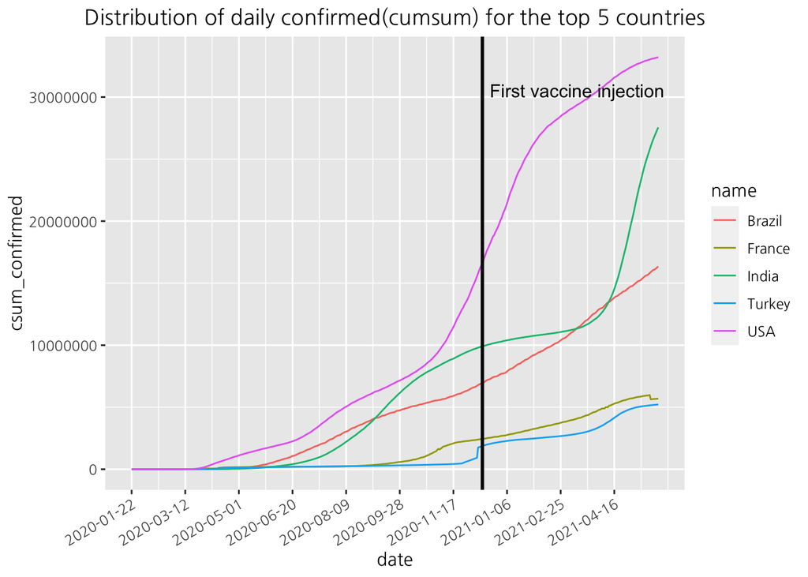

```r
covid_df %>%
  filter(name %in% top_confirmed_countries) %>%
  group_by(name) %>%
  mutate(csum_confirmed = cumsum(replace_na(confirmed, 0)),
         csum_death = cumsum(replace_na(death, 0)),
         csum_recovered = cumsum(replace_na(recovered, 0))) %>%
  group_by(name, date) %>%
  filter(row_number() == n()) %>%
  ggplot(aes(x = date, y = csum_confirmed, group = name)) +
  geom_line(aes(color = name)) +
  geom_vline(xintercept = as.numeric(ymd("2020-12-14")),
             color = 'black', size = 1) +
  geom_text(aes(x = as.Date('2020-11-01'), y = 30000000, label = 'First vaccine injection'),
            size = 4, vjust = 0, hjust = 0, nudge_x = 50, check_overlap = TRUE) +
  scale_x_continuous(breaks = seq(min(covid_df$date), max(covid_df$date), by = 50)) +
  ggtitle('Distribution of daily confirmed(cumsum) for the top 5 countries') +
  theme(plot.title = element_text(hjust=0.5),
        axis.text.x=element_text(angle=30, hjust=1))
```

위에서 이야기했던 것처럼 각 국가 별로 그 분포를 잘 확인할 수 있다.

미국은 세계에서 확진자 수가 가장 많은 국가이며, 인도는 최근 들어서 급격하게 그 추이가 증가하는 것을 확인할 수 있다.

또한 브라질은 꾸준히 확진자 수가 증가하는 모양을 확인할 수 있다. 그렇다면, 사망자 수의 추이는 어떻게 되는지 확인해보도록 한다.

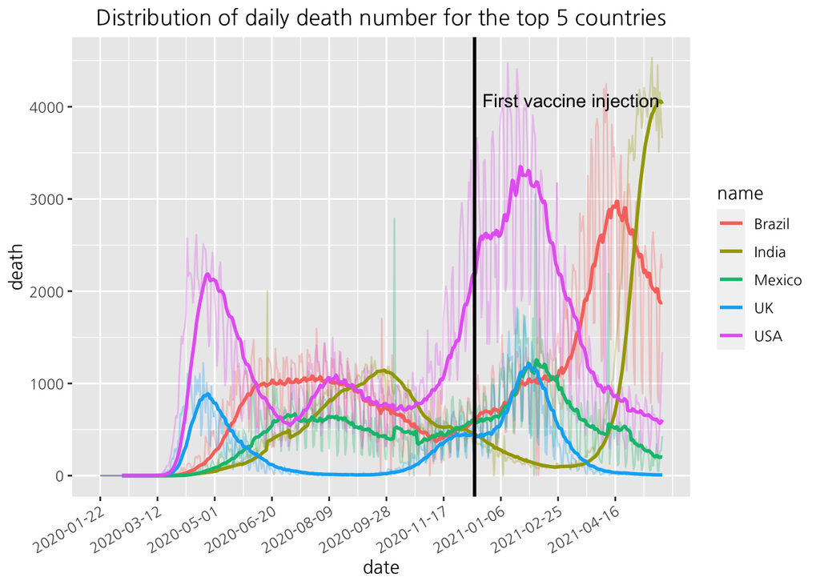

```r
covid_df %>%
  filter(name %in% top_death_countries) %>%
  group_by(name, date) %>%
  filter(row_number() == n()) %>%
  ggplot(aes(x = date, y = death, group = name)) +
  geom_line(aes(color = name), alpha = 0.3) +
  geom_ma(aes(color = name), ma_fun = SMA, n = 20, size = 1, linetype = 1) +
  geom_vline(xintercept = as.numeric(ymd("2020-12-14")),
             color = 'black', size = 1) +
  geom_text(aes(x = as.Date('2020-11-01'), y = 4000, label = 'First vaccine injection'),
            size = 4, vjust = 0, hjust = 0, nudge_x = 50, check_overlap = TRUE) +
  scale_x_continuous(breaks = seq(min(covid_df$date), max(covid_df$date), by = 50)) +
  ggtitle('Distribution of daily death number for the top 5 countries') +
  theme(plot.title = element_text(hjust=0.5),
        axis.text.x=element_text(angle=30, hjust=1))
```

그렇다면, 사망자 추이를 그래프로 표현해보도록 한다. 확인해보니 생각보다 너무 변동성이 커서 그래프를 확인하는데 약간의 어려움이 있었다.

따라서 tidyquant 패키지에 있는 geom_ma 함수를 통해서 20일 이동평균선으로 값을 표현하도록 한다.

기존의 사망자 추이 값은 alpha를 통해 약간 투명하게 표현했고, 이동평균선의 색을 더 진하게 표현하여 직관적으로 확인할 수 있도록 했다.

한편, 인도는 2021년 4월 이후 사망자 수가 급증하고 있는 것도 확인할 수 있다.

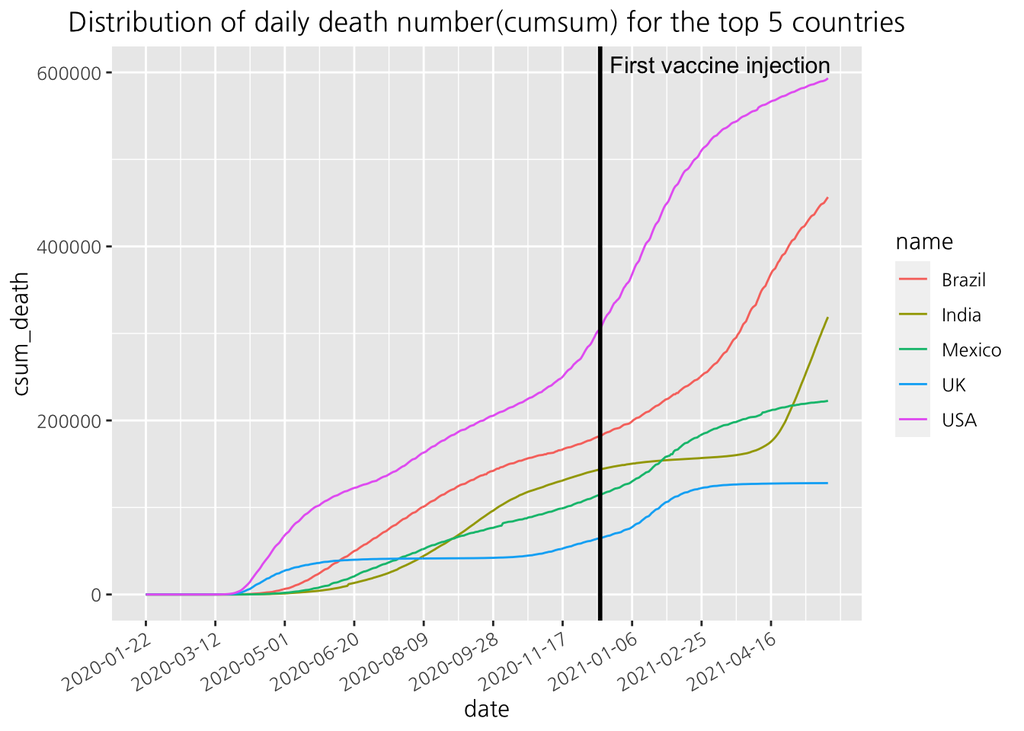

```r
covid_df %>%
  filter(name %in% top_death_countries) %>%
  group_by(name) %>%
  mutate(csum_confirmed = cumsum(replace_na(confirmed, 0)),
         csum_death = cumsum(replace_na(death, 0)),
         csum_recovered = cumsum(replace_na(recovered, 0))) %>%
  group_by(name, date) %>%
  filter(row_number() == n()) %>%
  ggplot(aes(x = date, y = csum_death, group = name)) +
  geom_line(aes(color = name)) +
  geom_vline(xintercept = as.numeric(ymd("2020-12-14")),
             color = 'black', size = 1) +
  geom_text(aes(x = as.Date('2020-11-01'), y = 600000, label = 'First vaccine injection'),
            size = 4, vjust = 0, hjust = 0, nudge_x = 50, check_overlap = TRUE) +
  scale_x_continuous(breaks = seq(min(covid_df$date), max(covid_df$date), by = 50)) +
  ggtitle('Distribution of daily death number(cumsum) for the top 5 countries') +
  theme(plot.title = element_text(hjust=0.5),
        axis.text.x=element_text(angle=30, hjust=1))
```

최종적으로는 누적 사망자 수를 확인해보도록 한다. 사망자 수가 가장 많은 국가는 미국이며, 브라질, 인도, 멕시코, 영국 순이라는 것을 알 수 있다.

사망자 수의 추이에 대한 기울기를 살펴보면, 미국은 백신 접종 이후 그 기울기가 비교적 감소한 것을 확인할 수 있다.

하지만 인도와 브라질은 아직 그 기세가 꺾이지 않은 것으로 보아 추가적인 대응책이 필요하다고 생각한다.